# Pairs Trading Simulation

Vince Trost

7/28/2017

# Introduction

This project comes from a textbook called *Data Science in R - A Case Studies Approach to Computational Reasoning and Problem Solving*, by Deborah Nolan and Duncan Temple Lang. This particular case study was contributed by Cari Kaufman of UC Berkeley and Duncan Temple Lang of UC Davis. I have a strong interest in leveraging Statistics and Machine Learning to trade algorithmically, so this case study appealed to me greatly. I try not to copy everything directly, so for some of the functions I implement my own code to complete the same task.

Pairs trading is essentially a way to leverage two positively cointegrated securities to make money. Developed in the 1980’s at Morgan Stanley, the idea is that two positively cointegrated securities will have a (relatively) steady ratio between their share prices. If you look at the ratio of the share prices of secutiry 1 to security 2, and they tend to fluctuate around a certain point, this shows that the pair is well suited for pairs trading. One can establish a historical average for the ratio between the two securities. It’s when the ratio moves away from the historical average that the opportunity to make money comes about. Quoting the textbook example: “if stock 1 is doing better than it typically does, relative to stock 2, then we should sell stock 1 and buy stock 2. This is called ‘opening a position’. Then, when the ratio returns to its historical average, we should buy stock 1 and sell stock 2. This is called ‘closing the position’.”

It’s easier to see visually.

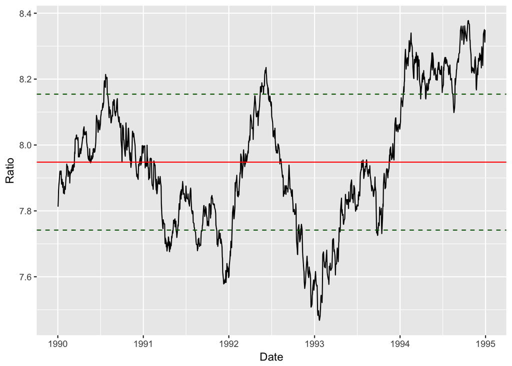

```r
#read in the data
sp500 <- read.csv("^GSPC.csv")
dow <- read.csv("^DJI.csv")

#put the S&P and Dow into one data frame- only interested in adjusted closing prices
dow <- dow %>% select(Date, Adj.Close)
sp500 <- sp500 %>% select(Date, Adj.Close)
sp_dj <- full_join(dow, sp500, by = 'Date')
names(sp_dj) <- c("Date", "Adj.Close_Dow", "Adj.Close_SP500")
#create the ratio
sp_dj$Ratio <- sp_dj$Adj.Close_Dow/sp_dj$Adj.Close_SP500
#format the date column
sp_dj$Date <- ymd(sp_dj$Date)

#make the graph function that accepts ratio, # of std devs, and line colors
plotRatio <- function(df, k = 1, col_mean = "red", col_sd = "darkgreen", db = "1 year", ...){
  ggplot(data = df, aes(x = Date, y = Ratio)) +
    geom_line() +
    scale_x_date(date_labels = "%Y", date_breaks = db) +
    geom_hline(yintercept = mean(df$Ratio), color = col_mean) +
    geom_hline(yintercept = (mean(df$Ratio) + k * sd(df$Ratio)), color = col_sd, linetype = "dashed") +
    geom_hline(yintercept = (mean(df$Ratio) - k * sd(df$Ratio)), color = col_sd, linetype = "dashed")
}
plotRatio(sp_dj)
```

Here we visualize the ratio between the share prices of the S&P 500 and the Dow Jones Index from 1990 to 1995. We can see that the ratio fluctuates around a mean of 7.95 (represented by the red line), and the standard deviation from that mean is 0.21 (represented by the dark green dashed lines). One would open a position when the ratio is above/below one of the green lines, and close the position when the ratio returns to the mean.

# Finding Pairs Suitable for Pairs Trading

One thing the book doesn’t go over until the end is if a pair of securities are even suitable for pairs trading. I thought that should be the first thing I do. I found through research that the base requirement is not correlation, but **cointegration**. For example, two stocks could both have an up day and be positively correlated, but the degree of correlation can vary greatly. There also could be no underlying reason as to why both stocks went up that is intuitive and explainable. However, I learned that if the two stocks are cointegrated, this means much more. Cointegration means that two stocks can fluctuate on a random walk, but the distance between them is bounded. The analogy I found in an article went like this: “A man was drinking in a pub and decided to leave, and he took his dog with him. They started walking home and came to an intersection, so the man put the dog on the leash. The drunk man was walking randomly, and so was the dog- but the distance between them at any given time was bounded by the leash. The man and dog were cointegrated.”

#### Future Development

I found an article in a tweet from Quantopian about how to use t-SNE and DBSCAN to identify pairs suitable for pairs trading [here](https://www.quantopian.com/posts/pairs-trading-with-machine-learning?utm_source=twitter&utm_medium=web&utm_campaign=pairs_trading_with_machine_learning). I’ve already successfully used this workflow in an internship to summarize Mutual Funds, so I’m very interested in exploring this more.

Once I understood the idea behind cointegration, I looked online to see how to test if two time series were cointegrated, and I came to [this](https://www.r-bloggers.com/time-series-cointegration-in-r/) blog post that had the following function. It takes two identical time series and outputs a p-value (< 0.05 means highly cointegrated).

```r
library(tseries)
cointegration<-function(x,y)
{
  vals<-data.frame(x,y)
  beta<-coef(lm(vals[,2]~vals[,1]+0,data=vals))[1]
  (adf.test(vals[,2]-beta*vals[,1], alternative="stationary", k=0))$p.value
}
```

Now I can test if any two stocks are suitable for pairs trading. For the sake of confirmation, let’s test the S&P 500 and the Dow Jones:

```r
cointegration(sp500$Adj.Close, dow$Adj.Close)
```

```
## [1] 0.8289649
```

Uh oh. Based on the Augmented Dickey-Fuller test, these two stocks over the ’90-’95 time period aren’t really suitable for pairs trading. This makes sense, because though this is the time the textbook uses for example, they do have to close a position at a loss because the 5 years is up.

# Finding Opening and Closing Positions

To visualize even more what we are doing here, we can highlight the positions on a ratio graph where we will open and close positions. We’ll start by writing a function to compute the “next” position given a starting position or day to start from. According to the text, this will allow us to use the function to find all of the positions.

This function will accept the ratio vector, the start day that will act as an index for the ratio vector, and a value for k. We can also add in the mean of the ratio and the standard deviation of the ratio.

```r
findNextPos <- function(ratio, startDay = 1, k = 1,
                        m = mean(ratio), s = sd(ratio)){
  #define the upper and lower bounds
  up <- m + k*s
  down <- m - k*s

  #if the start day isn't 1, you've got to prune your ratio vector accordingly
  if(startDay > 1)
    ratio <- ratio[-(1:(startDay-1))]


  #define a flag that turns true if the ratio goes above or below the bounds
  isExtreme <- ratio >= up | ratio <= down

  #if the ratio never crosses the bounds, return an integer
  if(!any(isExtreme))
    return(integer())

  #define 'start' as either above or below the ratio
  start <- which(isExtreme)[1]
  #define when it's back down to the mean
  backToNormal <- if(ratio[start] > up)
    ratio[-(1:start)] <= m
  else
    ratio[-(1:start)] >= m
  #return either the end of the position or the index of the end of the vector
  #it could return NA for not ended, i.e. #which(backToNormal)[1]
  #for both cases. But then the caller has to interpret that.

  end <- if(any(backToNormal))
    which(backToNormal)[1] + start
  else
    length(ratio)

  c(start, end) + startDay - 1
}
```

Now that we have a function, let’s test it on some data. For the sake of following the textbook’s example, I’m going to compare AT&T and Verizon. First, I want to see if these stocks are cointegrated. If they are, then I need to pre-process the data just like I did for the S&P500 and Dow Jones Index.

```r
#read in the data
att <- read.csv("T.csv")
vzw <- read.csv("VZ.csv")

#check for cointegration
cointegration(att$Adj.Close, vzw$Adj.Close)
```

```
## [1] 0.01
```

Great! These two stocks are highly cointegrated from ’90 - ’17!

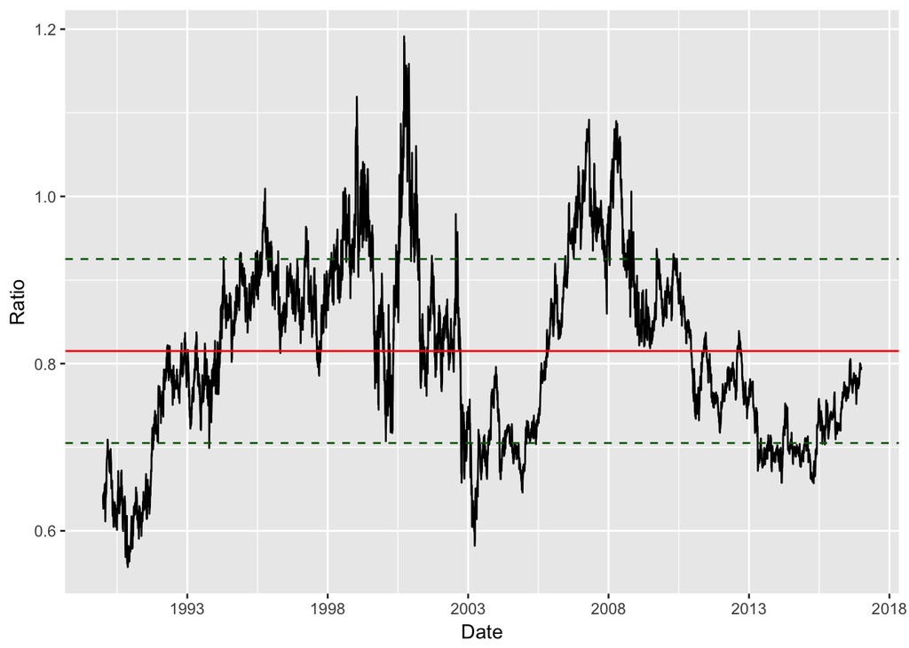

```r
#put AT&T and VZW into one data frame- only interested in adjusted closing prices
att <- att %>% select(Date, Adj.Close)
vzw <- vzw %>% select(Date, Adj.Close)
att_vzw <- full_join(att, vzw, by = 'Date')
names(att_vzw) <- c("Date", "Adj.Close_att", "Adj.Close_vzw")
#create the ratio
att_vzw$Ratio <- att_vzw$Adj.Close_att/att_vzw$Adj.Close_vzw
#format the date column using a lubridate function
att_vzw$Date <- ymd(att_vzw$Date)


## we already have that plotRatio function, so we might as well use it!
plotRatio(att_vzw, db = "5 years")
```

So we see that AT&T and Verizon are two stocks appropriate for pairs trading! Now we want to test the `findNextPos` function to see if it returns indices we expect…

```r
a <- findNextPos(att_vzw$Ratio)
a
```

```
## [1]   1 579
```

These are not the numbers we get in the text, but I suspect that’s due to myself using a different time frame for the data. This in turn changed the mean and standard deviation across the time period. Based on the graph, it makes sense that it should open a position immediately and in under 3 years we would close it because it reaches the average in the summer of ’92 (the data starts at 1990 and goes through 2016).

Using the fact that the `a` is vectorized, we can reference it in future function calls in order to find the positions that come after the first one.

```r
k = .85
b <- findNextPos(att_vzw$Ratio, a[2], k = k)
b
```

```
## [1] 883 918
```

```r
c <- findNextPos(att_vzw$Ratio, b[2], k = k)
c
```

```
## [1]  958 1007
```

Since we can find one position, we can use an iterative process in order to find all of the positions.

```r
#pass all the previous things
getPositions <- function(ratio, k = 1, m = mean(ratio), s = sd(ratio)){
  #initialize list and "current" date counter
  when = list()
  cur = 1

  #while the date is less than the number of entities in ratio,
  #find the next position. If findNextPos returns a vector of length 0,
  #we never open a position- this pair of stocks is not suitable for pairs trading.
  #If the closing position is the last date, the pair never reverted to the mean
  while(cur < length(ratio)){
    tmp <- findNextPos(ratio, cur, k, m, s)
    if(length(tmp) == 0)
      break
    when[[length(when) + 1]] = tmp
    if(is.na(tmp[2]) || tmp[2] == length(ratio))
      break
    cur = tmp[2]
  }
  return(when)
}
positions <- getPositions(att_vzw$Ratio)
positions
```

```
## [[1]]
## [1]   1 579
##
## [[2]]
## [1]  958 1007
##
## [[3]]
## [1] 1088 1159
##
## [[4]]
## [1] 1234 1595
##
## [[5]]
## [1] 1818 1928
##
## [[6]]
## [1] 2056 2446
##
## [[7]]
## [1] 2639 2855
##
## [[8]]
## [1] 2955 2981
##
## [[9]]
## [1] 3170 3210
##
## [[10]]
## [1] 3218 3986
##
## [[11]]
## [1] 4152 5282
##
## [[12]]
## [1] 5875 6805
```

Here we see the positions for AT&T and Verizon. Let’s plot them on a graph.

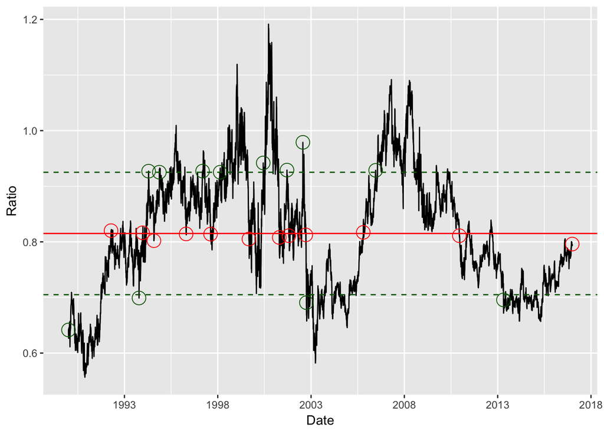

```r
showPositions <- function(df, positions, k = 1, col_mean = "red", col_sd = "darkgreen", db = "1 year", ...){
  open <- vector(mode = "numeric", length = length(positions))
  close <- vector(mode = "numeric", length = length(positions))
  for(i in 1:length(positions)){
    open[i] <- positions[[i]][1]
    close[i] <- positions[[i]][2]
  }
  p <- ggplot(data = df, aes(x = Date, y = Ratio)) +
    geom_line() +
    scale_x_date(date_labels = "%Y", date_breaks = db) +
    geom_hline(yintercept = mean(df$Ratio), color = col_mean) +
    geom_hline(yintercept = (mean(df$Ratio) + k * sd(df$Ratio)), color = col_sd, linetype = "dashed") +
    geom_hline(yintercept = (mean(df$Ratio) - k * sd(df$Ratio)), color = col_sd, linetype = "dashed")

  openers <- data.frame(matrix(nrow = length(positions), ncol = 2))
  closers <- data.frame(matrix(nrow = length(positions), ncol = 2))

  openers$Date <- df$Date[open]
  openers$Ratio <- df$Ratio[open]

  closers$Date <- df$Date[close]
  closers$Ratio <- df$Ratio[close]

  o <- geom_point(data = openers, aes(x = Date, y = Ratio), size = 5, color = "darkgreen", shape = 1)
  c <- geom_point(data = closers, aes(x = Date, y = Ratio), size = 5, color = "red", shape = 1)
  p + o + c
}


showPositions(att_vzw, positions, db = "5 years")
```

The green circles are where we would open positions, and the red circles are where we would close. We take advantage of the fact that the ratio is mean-reverting to make money. Now we can work on calculating how much we would actually make!

# Computing the Profit for a Position

We want to write a function to compute the profit for each position. It will be called `positionProfit()`, and it will take the position vector and the stock prices. The code will be commented to explain how it works.

```r
#pass the position list of vectors, stock prices, and the percentage we pay in commission of the total dollar amount
positionProfit <- function(pos, stockPriceA, stockPriceB, ratioMean = mean(stockPriceA/stockPriceB), p = 0.001, byStock = FALSE){

  #validate the pos object is a list of vectors, and if we want the profit by stock, create the df
  if(is.list(pos)){
    ans <- sapply(pos, positionProfit, stockPriceA, stockPriceB, ratioMean, p, byStock)
    if(byStock)
      rownames(ans) = c("A", "B", "commission")
    return(ans)
  }

  #get the stock prices at the start and end of each position
  priceA <- stockPriceA[pos]
  priceB <- stockPriceB[pos]

  #how many units can we buy of A and B with $1? (Generally a small fraction)
  unitsOfA <- 1/priceA[1]
  unitsOfB <- 1/priceB[1]

  #get the dollar amount of how many units we would buy of A and B
  #at the cost at the end of the position of each
  amt <- c(unitsOfA * priceA[2], unitsOfB * priceB[2])

  #figure out which stock we are selling
  sellWhat <- if(priceA[1]/priceB[1] > ratioMean)
    "A"
  else
    "B"

  #compute the profit based on which stock it was
  profit <- if(sellWhat == "A")
    c((1 - amt[1]), (amt[2] - 1), - p * sum(amt))
            else
              c((1 - amt[2]), (amt[1] - 1), -p * sum(amt))

  #if we want a more detailed look of the profit by position, set byStock = TRUE
  if(byStock)
    profit
  else
    sum(profit)

}
```

Now we want to test that this is working. We can test it on the first position for the DJI and GSPC.

```r
positionProfit(c(1,2), c(3838.48, 8712.87), c(459.11, 1100.65), p = 0)
```

```
## [1] 0.1274807
```

Based on the text, this is exactly what we want to see. And if we round this to two decimals, we see that on that position we made $0.13. Now we can see the profits for each position in our AT&T vs Verizon example…

```r
prof <- positionProfit(positions, att$Adj.Close, vzw$Adj.Close, p = 0)
prof
```

```
##  [1] 0.2318501 0.1579429 0.1545160 0.1726227 0.1396419 0.1920451 0.1455478
##  [8] 0.1279448 0.1826724 0.2036986 0.1889844 0.1741145
```

```r
sum(prof)
```

```
## [1] 2.071581
```

These values seem perfectly resonable, assuming there’s no commission fee. The text emphasizes being skeptical, but everything looks good!

# Finding the Optimal Value of K

We now can use the functions we created to find the best value of k from training data and apply it to test data. We will split the data into training and testing sets.

```r
#create the training and testing sets
i = 1:floor(nrow(att_vzw)/2)
train = att_vzw[i, ]
test = att_vzw[-i, ]
rtrain = train$Ratio
rtest = test$Ratio

#set the max value of k to look between
kmax <- max(rtrain)
#set the min value of k to look between
kmin <- min(rtrain)
#compute the sequence of calues for k that we want to explore
ks <- seq(kmin, kmax, length = 1000)
#compute the mean of the ratio just to have for later
m <- mean(att_vzw$Ratio)
```

Now we can loop over the different values of k and compute the profit for that strategy/rule defined by k:

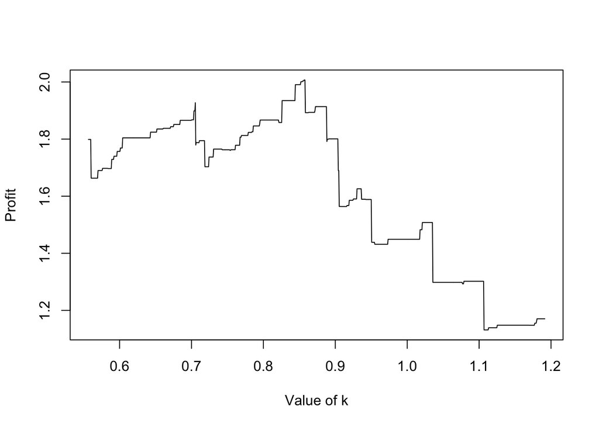

```r
profits <- sapply(ks,
                  function(k){
                    pos <- getPositions(rtrain, k)
                    sum(positionProfit(pos, train$Adj.Close_att, train$Adj.Close_vzw,
                                       ratioMean = mean(rtrain)))
                  })

plot(ks, profits, type = "l", xlab = "Value of k", ylab = "Profit")
```

Here we can visualize the distribution of profit for various values of `k`. It seems we max out our profit around 0.85 or so. Let’s see what it actually is…

```r
ks[profits == max(profits)]
```

```
## [1] 0.8565283 0.8571636 0.8577990
```

These are the values for `k` which maximize our profits! Ideally we want one value but these signify the flat region up at the top of our distribution.